# White wine qualities exploration by Wu Qihua

### 11、alcohol：酒精含量

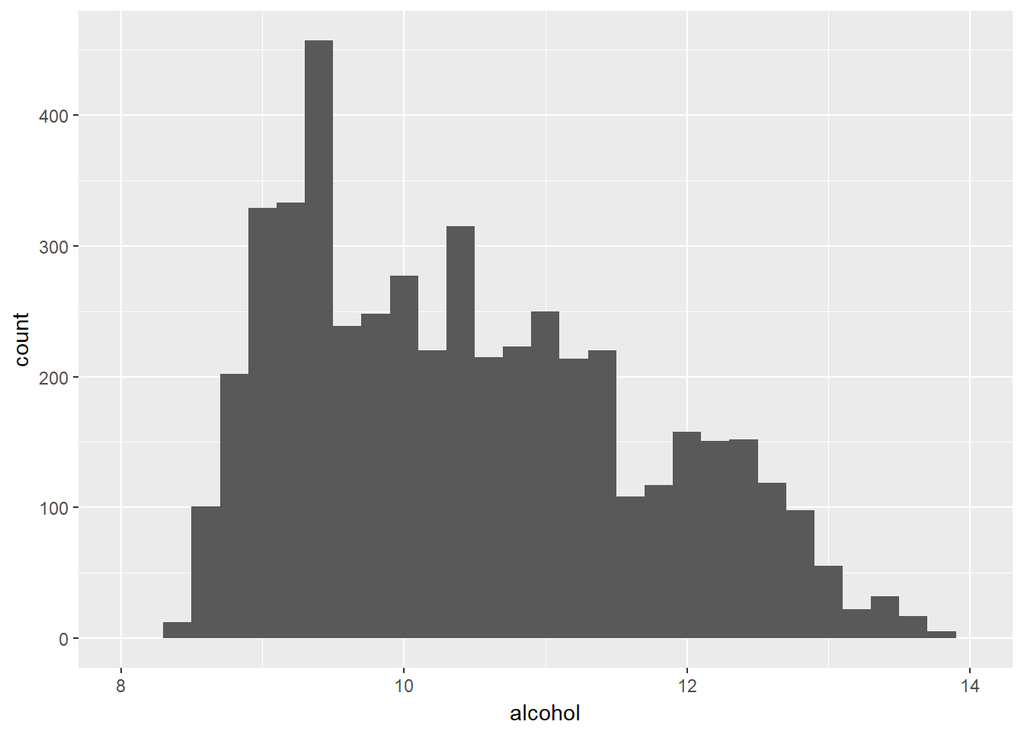

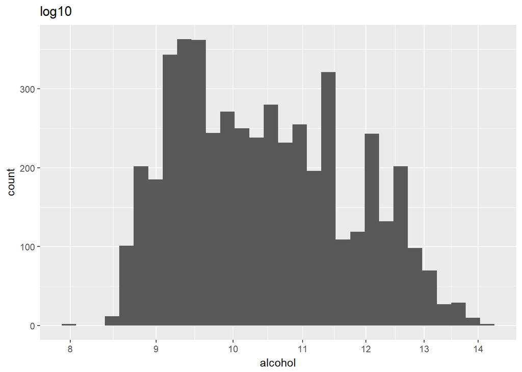

```
##    Min. 1st Qu.  Median    Mean 3rd Qu.    Max.
##    8.00    9.50   10.40   10.51   11.40   14.20
```

从统计数据来看，绝大部分酒精含量数据在8~14之间，从第一个直方图可以看出酒精含量数据呈右偏肥尾分布，峰值在9.5附近，但并非偏态分布，因为通过对数转换后，在第二个直方图看不出明显的分布形态。

### 12、quality：质量评分

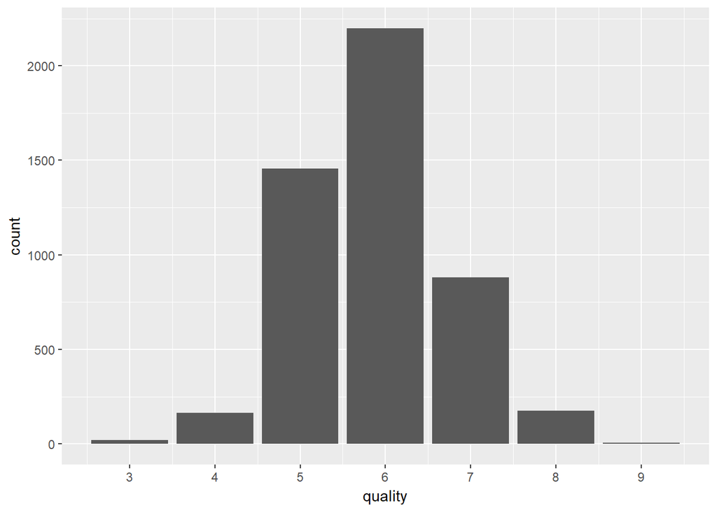

```
##    Min. 1st Qu.  Median    Mean 3rd Qu.    Max.
##   3.000   5.000   6.000   5.878   6.000   9.000
```

可以看出质量评分数据大体呈正态分布，所有数据在3~9之间，峰值在6。

但评分是一个离散的数据，应视为此数据集中的有序因子变量。

# 单变量分析

### 你的数据集结构是什么？

我选择的数据集中有4898个观察样本，13个变量，即X, fixed.acidity, volatile.acidity, citric.acid, residual.sugar, chlorides, free.sulfur.dioxide, total.sulfur.dioxide, density, pH, sulphates, alcohol, quality。

其中X是每个葡萄酒样本的编号，quality是评分由差到好按从0到10的整数记录，因此应是有序因子变量。

其他观察：

- density变量的差异较少。
- 葡萄酒的pH在2.7~ 3.8之间，偏酸性，酒精含量在8~14%之间，符合常识。
- 大部分葡萄酒的quality在5~7之间，最高为9，但仅有5个样本。

### 你的数据集内感兴趣的主要特性有哪些？

葡萄酒的质量评分，通过与其他变量的分析希望得出评分较高的葡萄酒的特点。

### 你认为数据集内哪些其他特征可以帮助你探索兴趣特点？

其余所有变量都有助于对质量评分的探索。

### 根据数据集内已有变量，你是否创建了任何新变量？

利用residual.sugar创建了新变量variety，赋值dry为residual.sugar < 4，赋值semi-dry为residual.sugar = [4,2)，赋值not-dry为residual.sugar >= 12。

虽然非挥发性酸、挥发性酸和柠檬酸能组合成酸类物的数据，但评价酸性按pH变量会更直观，但pH与quality的相关性并不大。

### 在已经探究的特性中，是否存在任何异常分布？你是否对数据进行一些操作，如清洁、调整或改变数据的形式？如果是，你为什么会这样做？

大部分变量在调整组距和对x轴范围进行限制排除部分偏离值后，都大体呈正态分布，除了：

- volatile.acidity和sulphates变量呈正偏态分布，通过对数转换可以看出其正态分布结构。
- residual.sugar的分布是按照糖分分类的多个种类葡萄酒的分布组合，对其进行对数转换可以看出双峰结构。
- alcohol呈右偏的肥尾分布。
- chlorides的偏离值较多，排除偏离值后呈正态分布。
- citric.acid的分布在0.49和0.74有异常值，推测与规格有关，但仍能观察出其正态分布，因此未作处理。

# 双变量绘图选择

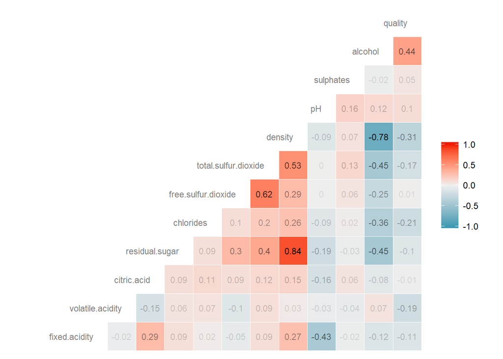

从相关性矩阵可以看出，与质量评分相关性最高的两个个分别是alcohol(0.436)和density(-0.307)，但alcohol和density之间的相关性高达-0.780，可见葡萄酒的酒精含量和密度关联很大，因为酒精的密度比水要小。

此外，虽然相关性不高，但我还想观察residual.sugar和quality的关系，因为新添加变量variety与之有关。不过residual.sugar和density的相关性亦高达0.839，这是因为糖的密度要远远比液体高。因此在双变量绘图选择里，选取alcohol、density和residual.sugar与quality之间的探索性分析、观察。

### alcohol与quality

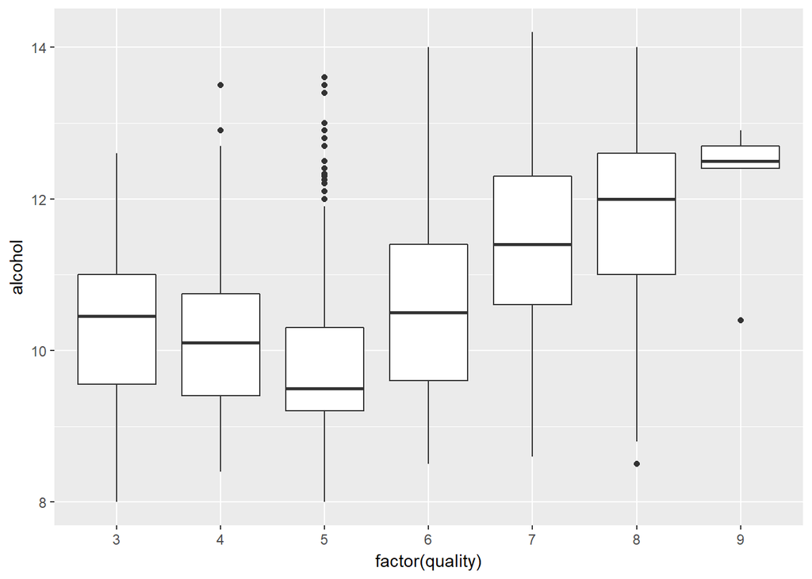

```
## wines$quality: 3
##    Min. 1st Qu.  Median    Mean 3rd Qu.    Max.
##    8.00    9.55   10.45   10.35   11.00   12.60
## --------------------------------------------------------
## wines$quality: 4
##    Min. 1st Qu.  Median    Mean 3rd Qu.    Max.
##    8.40    9.40   10.10   10.15   10.75   13.50
## --------------------------------------------------------
## wines$quality: 5
##    Min. 1st Qu.  Median    Mean 3rd Qu.    Max.
##   8.000   9.200   9.500   9.809  10.300  13.600
## --------------------------------------------------------
## wines$quality: 6
##    Min. 1st Qu.  Median    Mean 3rd Qu.    Max.
##    8.50    9.60   10.50   10.58   11.40   14.00
## --------------------------------------------------------
## wines$quality: 7
##    Min. 1st Qu.  Median    Mean 3rd Qu.    Max.
##    8.60   10.60   11.40   11.37   12.30   14.20
## --------------------------------------------------------
## wines$quality: 8
##    Min. 1st Qu.  Median    Mean 3rd Qu.    Max.
##    8.50   11.00   12.00   11.64   12.60   14.00
## --------------------------------------------------------
## wines$quality: 9
##    Min. 1st Qu.  Median    Mean 3rd Qu.    Max.
##   10.40   12.40   12.50   12.18   12.70   12.90
```

从各评分之间的alcohol统计数据看出，4分及以下的白葡萄酒有一半左右酒精含量小于10%，而8分及以上的白葡萄酒有一半以上酒精含量在12%以上。

从箱线图容易看出酒精含量和质量评分的关系和趋势，3 ~ 5分的白葡萄酒，评分越高，其酒精含量的中位数和平均值越低，5 ~ 9分白的葡萄酒，评分越高，其酒精含量的中位数和平均值越高。

虽然评分为3和评分为9的样本数都很少，但总体来说，确实存在一定的趋势使得酒精含量和评分之间有一定的正相关关系。

### density与quality

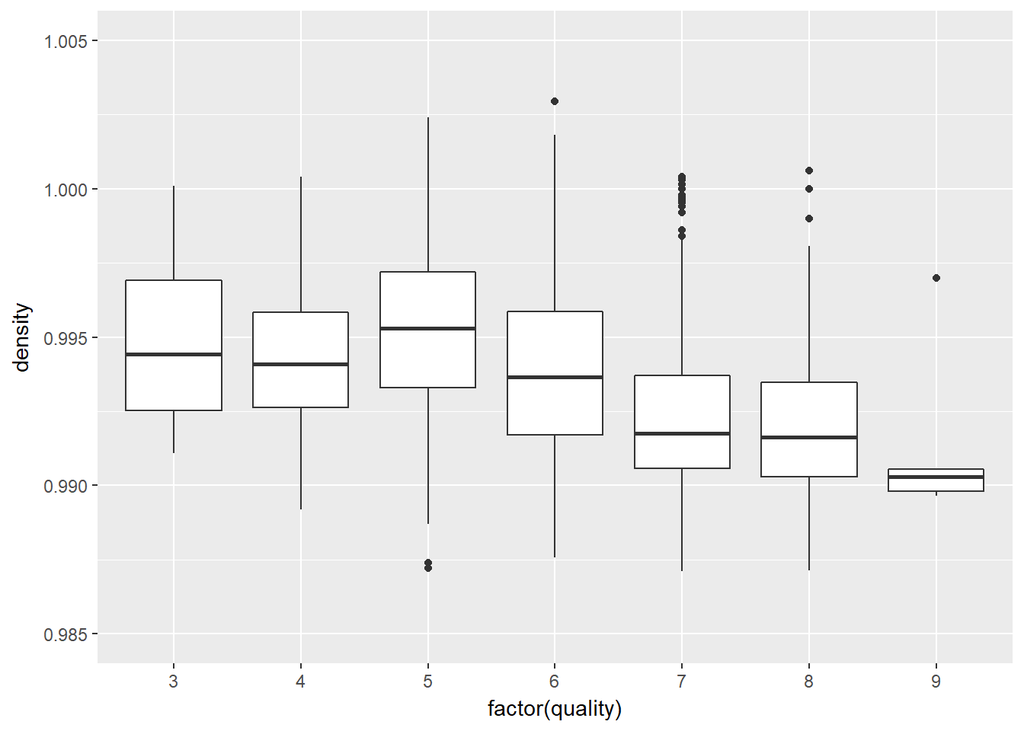

```
## wines$quality: 3
##    Min. 1st Qu.  Median    Mean 3rd Qu.    Max.
##  0.9911  0.9925  0.9944  0.9949  0.9969  1.0001
## --------------------------------------------------------
## wines$quality: 4
##    Min. 1st Qu.  Median    Mean 3rd Qu.    Max.
##  0.9892  0.9926  0.9941  0.9943  0.9958  1.0004
## --------------------------------------------------------
## wines$quality: 5
##    Min. 1st Qu.  Median    Mean 3rd Qu.    Max.
##  0.9872  0.9933  0.9953  0.9953  0.9972  1.0024
## --------------------------------------------------------
## wines$quality: 6
##    Min. 1st Qu.  Median    Mean 3rd Qu.    Max.
##  0.9876  0.9917  0.9937  0.9940  0.9959  1.0390
## --------------------------------------------------------
## wines$quality: 7
##    Min. 1st Qu.  Median    Mean 3rd Qu.    Max.
##  0.9871  0.9906  0.9918  0.9925  0.9937  1.0004
## --------------------------------------------------------
## wines$quality: 8
##    Min. 1st Qu.  Median    Mean 3rd Qu.    Max.
##  0.9871  0.9903  0.9916  0.9922  0.9935  1.0006
## --------------------------------------------------------
## wines$quality: 9
##    Min. 1st Qu.  Median    Mean 3rd Qu.    Max.
##  0.9897  0.9898  0.9903  0.9915  0.9906  0.9970
```

在箱线图中放大实体部分，5~9分的白葡萄酒其趋势较容易看出，评分越高则其密度的中位数和平均数越低。

除了5分之外其他评分的白葡萄酒其密度中位数和平均值少于0.995g/dm^3。

### residual.sugar与quality

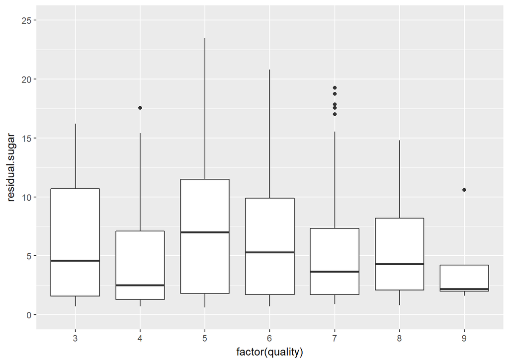

```
## wines$quality: 3
##    Min. 1st Qu.  Median    Mean 3rd Qu.    Max.
##   0.700   1.587   4.600   6.393  10.700  16.200
## --------------------------------------------------------
## wines$quality: 4
##    Min. 1st Qu.  Median    Mean 3rd Qu.    Max.
##   0.700   1.300   2.500   4.628   7.100  17.550
## --------------------------------------------------------
## wines$quality: 5
##    Min. 1st Qu.  Median    Mean 3rd Qu.    Max.
##   0.600   1.800   7.000   7.335  11.500  23.500
## --------------------------------------------------------
## wines$quality: 6
##    Min. 1st Qu.  Median    Mean 3rd Qu.    Max.
##   0.700   1.700   5.300   6.442   9.900  65.800
## --------------------------------------------------------
## wines$quality: 7
##    Min. 1st Qu.  Median    Mean 3rd Qu.    Max.
##   0.900   1.700   3.650   5.186   7.325  19.250
## --------------------------------------------------------
## wines$quality: 8
##    Min. 1st Qu.  Median    Mean 3rd Qu.    Max.
##   0.800   2.100   4.300   5.671   8.200  14.800
## --------------------------------------------------------
## wines$quality: 9
##    Min. 1st Qu.  Median    Mean 3rd Qu.    Max.
##    1.60    2.00    2.20    4.12    4.20   10.60
```

即使放大实体部分后，不易看出残留糖分和评分之间的关系和趋势，除了在各评分中residual.sugar的Q1差距并不大。

```
## [1] "counts of quality by variety"
```

```
## wines$variety: dry
##    Min. 1st Qu.  Median    Mean 3rd Qu.    Max.
##    3.00    5.00    6.00    5.95    7.00    9.00
## --------------------------------------------------------
## wines$variety: semi-dry
##    Min. 1st Qu.  Median    Mean 3rd Qu.    Max.
##   3.000   5.000   6.000   5.852   6.000   9.000
## --------------------------------------------------------
## wines$variety: not-dry
##    Min. 1st Qu.  Median    Mean 3rd Qu.    Max.
##    3.00    5.00    6.00    5.76    6.00    8.00
```

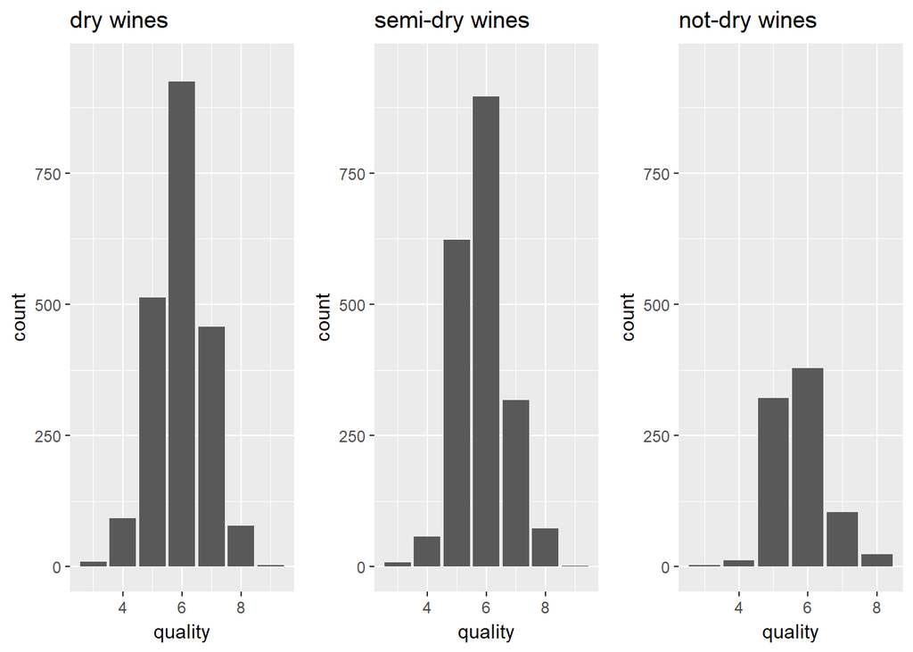

不过在单变量分析中，已解释到葡萄酒根据糖分可分为多种类型的葡萄酒，在上面根据variety分类的统计数据里，可以看出其实各类葡萄酒的样本在各评分中分布有一定差别，干白葡萄酒的正态分布更对称，5分和7分的数量相比其他类型更相近，即5分比例更小而7分的比例更高，而非干白葡萄酒的5分比例更高。

### alcohol与density

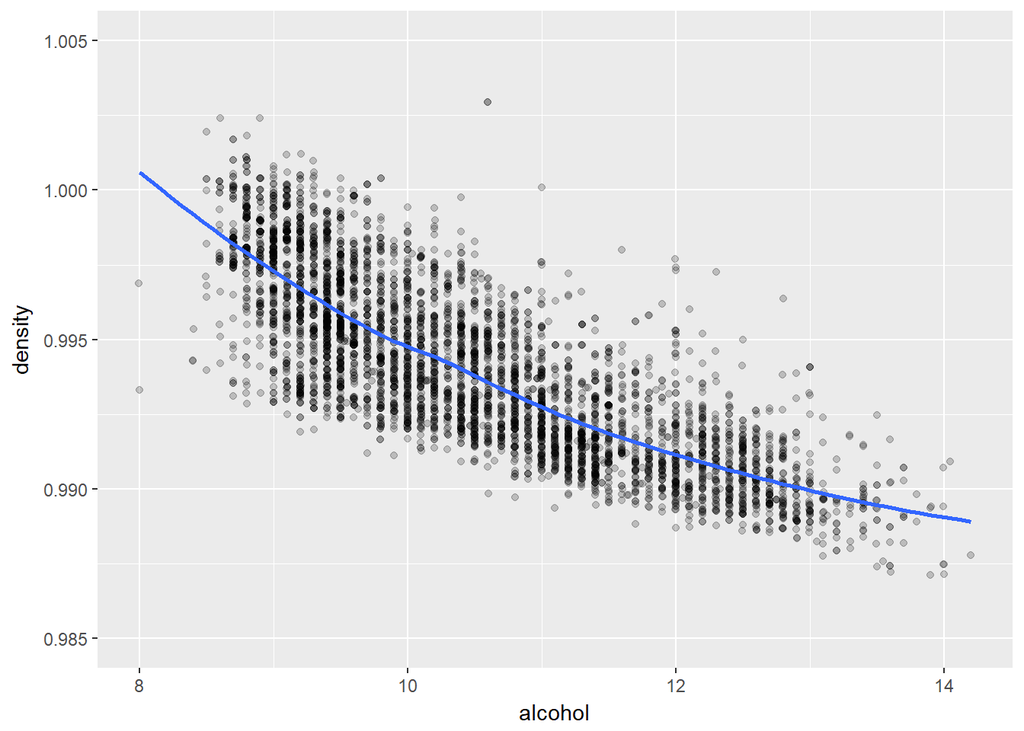

酒精含量和密度之间的点分布图，从局部加权回归曲线可看抛物线呈一定的负相关性。

### residual.sugar与density

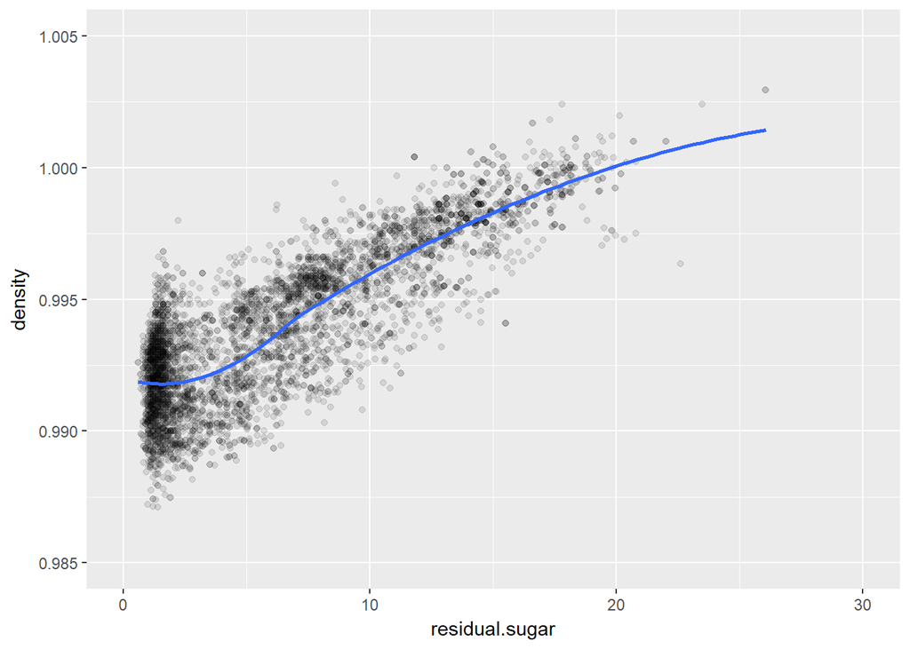

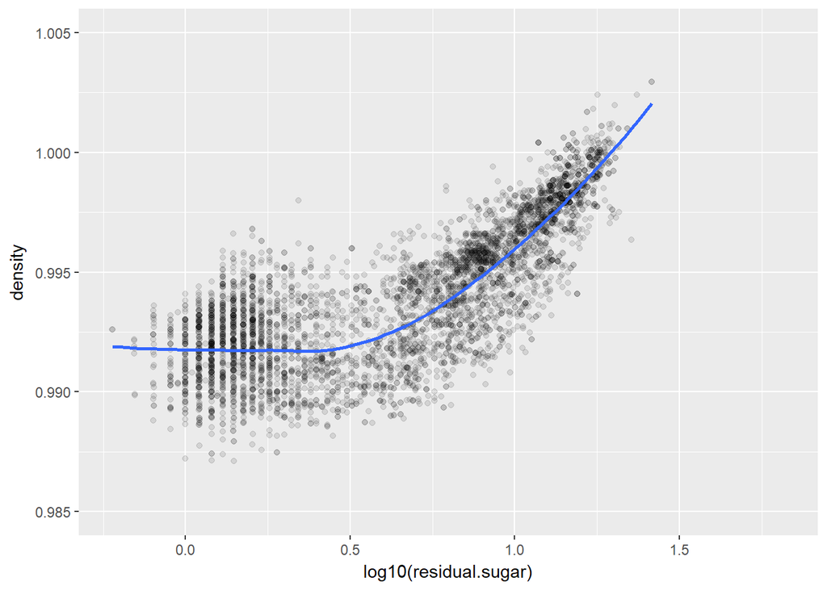

残留糖分和密度之间的点分布图，在对数图中可以看出，在ln(residual.sugar)小于0.5，加权曲线比较水平，大于0.5则与密度呈一定正相关关系。

### residual.sugar与alcohol

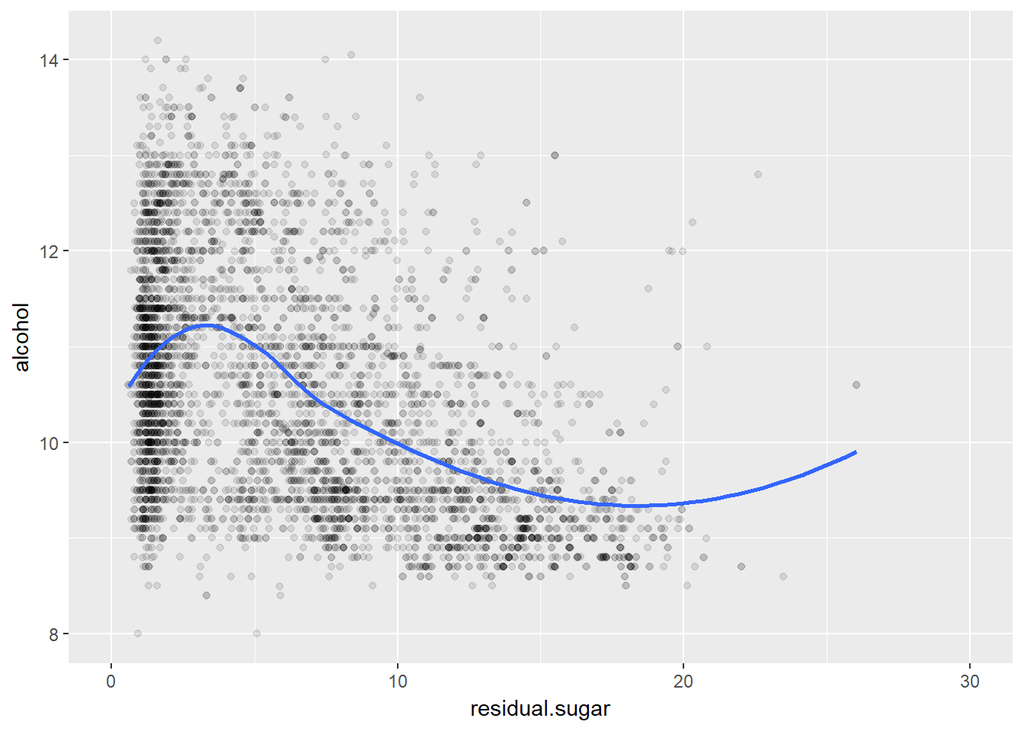

残留糖分和酒精之间的点分布图并没有明显的线性关系，不过酒精含量越小时，残留糖分的分布越广，酒精含量越大时，残留糖分的分布更偏向左侧即更小，因此点状图呈近似三角形的分布。

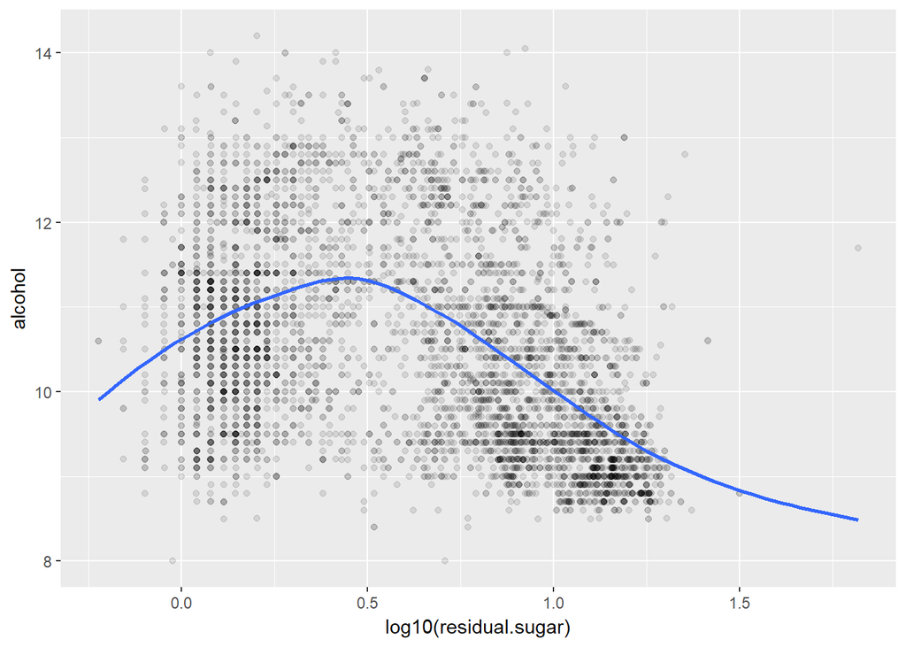

若对residual.sugar取对数，则可以从加权曲线中看出其关系，ln(residual.sugar)少于0.5时有正相关性，而大于0.5时有负相关性。

# 双变量分析

### 探讨你在这部分探究中观察到的一些关系。这些感兴趣的特性与数据集内其他特性有什么区别？

- 质量评分与酒精含量、密度之间的关系可能较高，与其他变量之间的关系可能较低。
- 酒精含量越高，则获得越高评分的可能性更大。
- 密度越低，则获得越高评分的可能性更大。
- 在所有样本中，虽然残留糖分和评分之间的关系不大，但若聚焦在糖分小于4g/dm^3的样本中，则可以观察到与评分之间的一定关系。

### 你是否观察到主要特性与其他特性之间的有趣关系？

密度和残留糖分、酒精含量有很强的关系，因为他们是相关的变量，糖分密度比水大而酒精密度比水小。

### 你发现最强的关系是什么？

残留糖分和密度之间的相关性最高，达到0.839。这是因为糖分的密度比水要高得多，因此糖分含量越高，则葡萄酒的密度越高。

# 多变量绘图选择

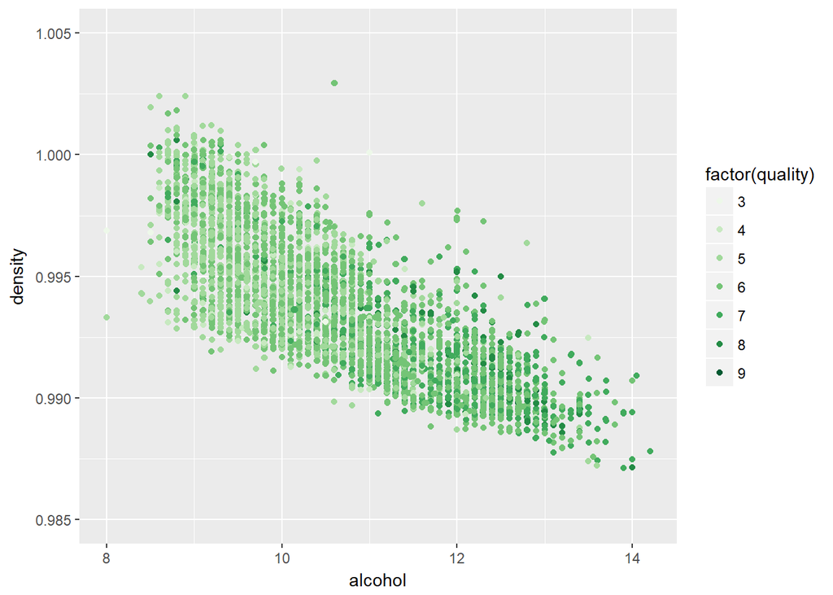

从点状图可以看出，靠左侧的葡萄酒样本颜色更浅，高质量评分比左侧更聚集。

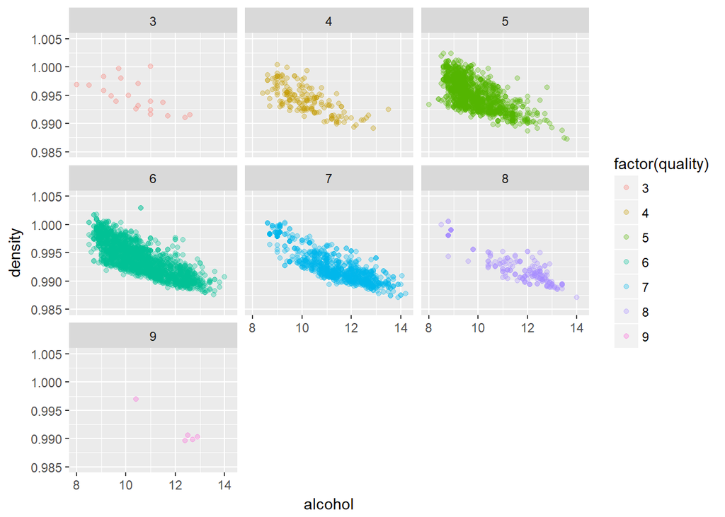

对quality进行切片后的图，可以看到3 ~ 5分的点分布集中在左上，6 ~ 7分的点在x轴上分布较平均，而8 ~ 9分的点分布集中在右下。

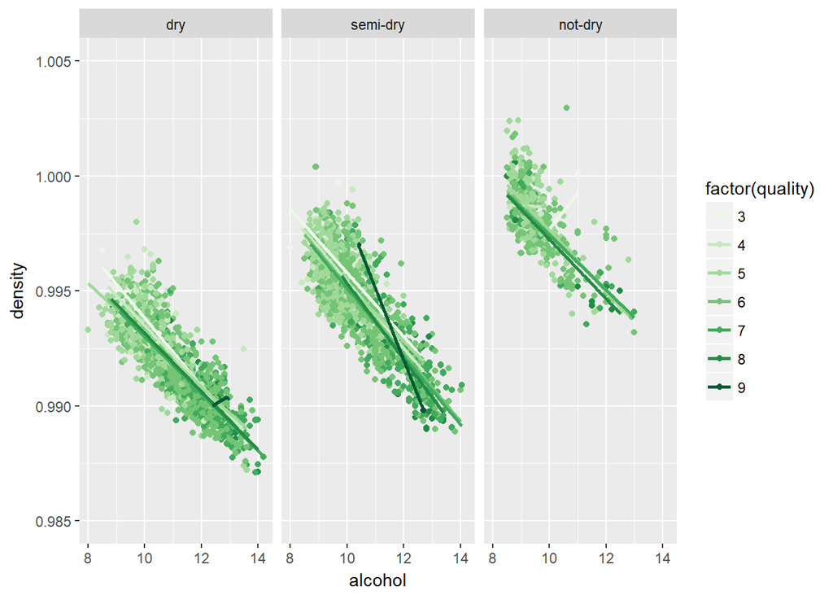

根据variety切片并加入线性关系后，可以看到糖分较低的葡萄酒都聚集在图型下方。

在alcohol和density的拟合直线中，4~8分相差并不大，3分和9分的相比其他评分的倾斜度有一定差距。

```
## wines$variety: dry
##    Min. 1st Qu.  Median    Mean 3rd Qu.    Max.
##    3.00    5.00    6.00    5.95    7.00    9.00
## --------------------------------------------------------
## wines$variety: semi-dry
##    Min. 1st Qu.  Median    Mean 3rd Qu.    Max.
##   3.000   5.000   6.000   5.852   6.000   9.000
## --------------------------------------------------------
## wines$variety: not-dry
##    Min. 1st Qu.  Median    Mean 3rd Qu.    Max.
##    3.00    5.00    6.00    5.76    6.00    8.00
```

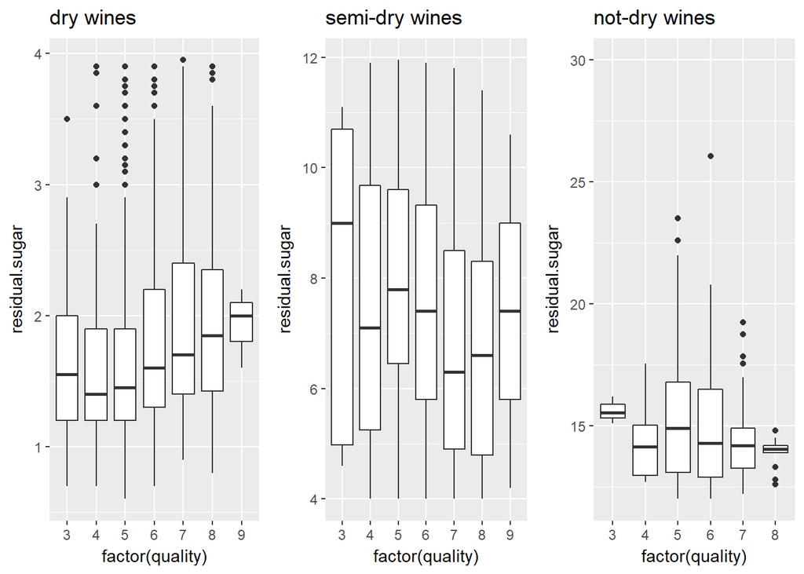

从箱线图可以看出，评分为4~9分的干白葡萄酒中，评分越高则糖分的中位数越大。在半干白葡萄酒里，糖分和评分的关系不易观察。而在非干白葡萄酒里，并没有9分的评分，糖分的各个中位数较接近，而且只有5和6分中的某些白葡萄酒里，糖分超过20g/dm^3 。

```
##
## Calls:
## m1: lm(formula = I(quality) ~ alcohol, data = wines)
## m2: lm(formula = I(quality) ~ alcohol + density, data = wines)
## m3: lm(formula = I(quality) ~ alcohol + density + residual.sugar,
##     data = wines)
## m4: lm(formula = I(density) ~ alcohol + residual.sugar, data = wines)
##
## ===========================================================================
##                        m1            m2            m3            m4
##                  ------------- ------------- ------------- --------------
##                    I(quality)    I(quality)    I(quality)    I(density)
## ---------------------------------------------------------------------------
##   (Intercept)         2.582***    -22.492***     90.313***       1.005***
##                      (0.098)       (6.165)      (12.374)        (0.000)
##   alcohol             0.313***      0.360***      0.246***      -0.001***
##                      (0.009)       (0.015)       (0.018)        (0.000)
##   density                          24.728***    -87.886***
##                                    (6.079)      (12.317)
##   residual.sugar                                  0.053***       0.000***
##                                                  (0.005)        (0.000)
## ---------------------------------------------------------------------------
##   R-squared           0.190         0.192         0.210          0.907
##   adj. R-squared      0.190         0.192         0.210          0.907
##   sigma               0.797         0.796         0.787          0.001
##   F                1146.395       583.290       434.085      23791.076
##   p                   0.000         0.000         0.000          0.000
##   Log-likelihood  -5839.391     -5831.127     -5776.812      27328.019
##   Deviance         3112.257      3101.773      3033.737          0.004
##   AIC             11684.782     11670.255     11563.624     -54648.037
##   BIC             11704.272     11696.241     11596.107     -54622.051
##   N                4898          4898          4898           4898
## ===========================================================================
```

对评分与上方选择的各变量进行线性回归，与quality相关性最高的alcohol的R^2即拟合度即可解释19%的葡萄酒评分变动，而加入density后则能增加到19.2%，再加入residual.sugar后增加到21%。

若对特征变量之间即密度与酒精含量、糖分含量进行线性回归，则可以得到0.907的拟合度，这也解释了他们之间的高相关性。

# 多变量分析

### 探讨你在这部分探究中观察到的一些关系。通过观察感兴趣的特性，是否存在相互促进的特性？

酒精含量和密度是一对互相促进的特性，酒精含量越高、密度越低的葡萄酒，质量评分越高。

在干葡萄酒中，残留糖分越高，则评分倾向越高。

### 这些特性之间是否存在有趣或惊人的联系呢？

在4~8分的葡萄酒中，alcohol和density之间的一元线性模型差距不大，但3分和9分的拟合直线和其他分数有明显差异。

酒精含量相似的葡萄酒样本中，干型葡萄酒的密度更小。

### 选项：你是否创建过数据集的任何模型？讨论你模型的优缺点。

我建立了用选择的变量与quality之间的多元线性模型，但该模型的拟合度R^2只有0.2左右。

因此我认为简单的线性模型在此数据集中的拟合效果并不强，如果需要有较好的预测力时可能并不太适合。

此外，我尝试了对所有的变量进行多元乘积的线性模型，得出0.9222的R^2，但缺点是模型复杂、计算速度极慢，而且有过拟合的嫌疑。

# 定稿图与总结

### 绘图一

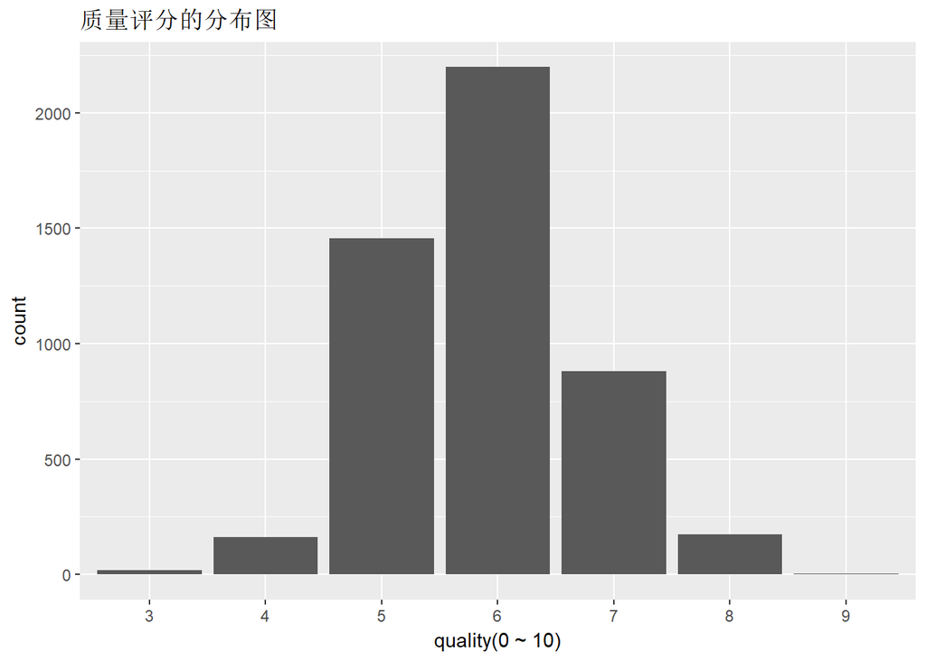

### 描述一

白葡萄酒的质量评分是呈众数为6的近似正态分布，quality的范围在3 ~ 9之间，评分越中庸，数量越多，评分越高或越低，数量越少。

### 绘图二

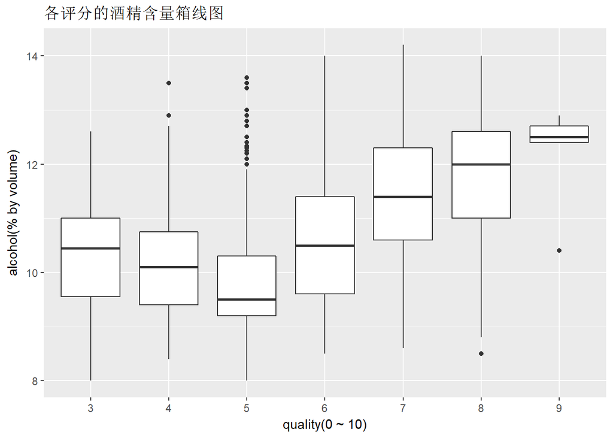

### 描述二

从箱线图可以看到质量评分quality和酒精含量alcohol之间的关系。

3 ~ 5分的葡萄酒，评分越高，则其酒精含量的Q1、Q3和中位数越低。

而5 ~ 9分的葡萄酒，评分越高，则其酒精含量的Q1、Q3和中位数越高。

### 绘图三

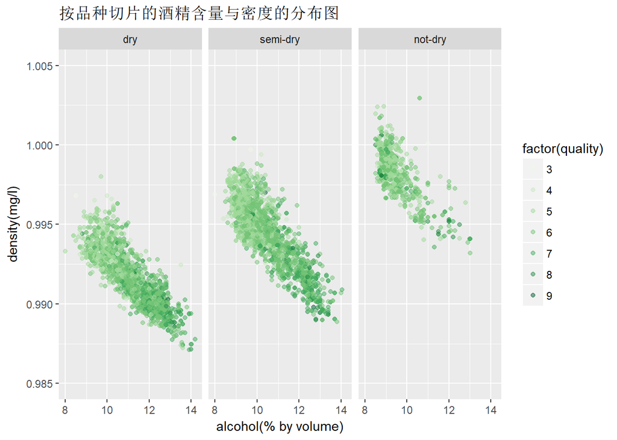

### 描述三

按照糖分含量分成了三个品种后，可以从点状图中看到酒精含量、密度与评分之间的关系。

从图形的形状可以看出alcohol和density之间有一定的线性关系，按照颜色深浅的集中度可以看出酒精含量越高、密度越低时，质量评分越高。

从各切片小图可以看出，在干白葡萄酒和半干白葡萄酒中，上述关系的分布更广，而非干白葡萄酒中分布更集中在高密度低酒精含量的区域。

# 反思

此白葡萄酒数据集一功有4898个有效样本和12个有效变量。在本次探索性分析中，一开始从单一变量出发，理解了每个变量的分布特性。此后则着重观察和探索各变量与质量评分quality之间的关系。此外，通过观察糖分含量变量residual.sugar，也发现了白葡萄酒的品种可以按照糖分含量来分类。

密度与酒精含量以及密度与糖分含量之间具有明显的趋势，而且密度和酒精含量是与评分相关性最高的两个变量，因此可以利用这几个变量来预测评分。但变量之间的线性回归模型做得并不理想，虽然可以做出一个拟合度高的模型，但缺点非常明显，我认为可行性不高。

模型失败的一个原因是对r语言的模型了解不多，二是因为各变量与quality之间的相关性并不高，三是因为评分可能并不是一个很好的线性回归模型的因变量，因为quality应该是数据集中的因子，其连续线性并不强，不过我估计如果用聚类可能效果会更好，但并不太懂怎么做。

此外，对其他变量的探索亦不够充分，如探索其他特征变量之间的关系，可能会得出更有趣的结论，但我认为着重探索评分相关性较高的变量还是有现实意义的。

最后，此分析报告对数据的分析并不够完善，因此在未来的工作中还有很多可以改进的地方。

一是本次分析报告并没有对所有的变量进行多变量分析，以至于并没有得出更多有趣的结论。而数据集中多达12个变量若互相之间进行分析则显得臃肿，因此我认为某些同类型的变量进行合并，比如fixed.acidity、volatile.acidity和citric.acid都是代表酸含量，可以利用某种方法合并成一个变量。另一个方法是对某些变量如本次分析中的residual.sugar一样进行分组，以达到有效去除噪音，能更好发现数据中的规律，这需要学习更多数据处理的知识以及理解各变量的内涵。

二是本次分析报告对模型的处理比较简单，在学习了机器学习章节的知识后，我认为结合上述的变量合并处理或如利用PCA等方法降维，能使模型有效提升性能。

三是在多变量分析中未能呈现更好的视觉效果，在数据处理、可视化规范与美学方面尚需要提高。

这些改进都需要继续加强对R语言和数据分析的学习，希望未来在知识体系更完善时能将报告修改得更丰富。